# Part 2: GRAPHICS: Looking at Statistics

## Agenda:

- Rules and resources for creating excellent plots
- Learning `matplotlib` - the main Python package used for plotting
- New plotting tools: **plot.ly**
- Anything else cool we find want to discuss.

### Begin by importing the packages we'll use.

```python
import os
import numpy as np
import urllib
import statsmodels.api as sm
import pandas as pd
import matplotlib.pyplot as plt
import pylab as pyl
from IPython.display import Image, YouTubeVideo, IFrame

# This is an example of an iPython magic command.
# If we don't use this, then we can't see our matplotlib plots in our notebook
%matplotlib inline
```

## Creating Excellent Plots

### Let's set the stage:

- Yesterday I mentioned why I like iPython Notebook.
- Today we get see a lot of its capabilities.
- We'll embed images from the web, check out a YouTube video, and build some powerful visualizations

## Data looks better naked

What in the world does that mean?

- Slide and data presentation often refers back to Edward Tufte and his book **"The Visual Display of Quantitative Information."**
- He offers many rules for data and presentation that are rooted in solid design principles.
- For our purposes today, naked data is this:

> **Data-ink is the non-erasable core of the graphic, the non-redundant ink arranged in response to variation in the numbers represented**
- If we remove all non-data-ink and redundant data-ink, within reason, we should be left with an informative graphic that reflects sound graphical design

> **“Perfection is achieved not when there is nothing more to add, but when there is nothing left to take away” – Antoine de Saint-Exupery**

```python
Image(url='http://darkhorseanalytics.com/blog/wp-content/uploads/2013/08/data-ink.gif')
```

[figure not shown]

## Sidebar for a discussion of presentation graphics

- Walk-through of a presentation from Des Traynor ([@destraynor](http://twitter.com/destraynor))
- [From Data To Insight](https://speakerdeck.com/destraynor/from-data-to-insight)
- We'll walk through this on the web; you can download a PDF directly from the site.

#### We can also look at YouTube videos thanks to iPython.

- Here is a 4 minute video by Edward Tufte inline in our notebook.
- Link is here: [Edward Tufte: The Beautiful Evidence (Highlights)](https://www.youtube.com/watch?v=Th_1azZA2OY)

```python
YouTubeVideo('Th_1azZA2OY')
```

[video not shown]

### Homework / Further Reading

- Two awesome resources always on my desk

[figure not shown]

- Edward Tufte: [The Visual Display of Quantitative Information](http://www.amazon.com/Visual-Display-Quantitative-Information/dp/0961392142/)

[figure not shown]

- Stephen Few: [Show Me The Numbers](http://www.amazon.com/gp/product/0970601972/)

# Learning the basics of matplotlib

```python
# First generate some dummy data
X = np.linspace(-np.pi, np.pi, 256,endpoint=True)
C,S = np.cos(X), np.sin(X)
```

## Using defaults

> Matplotlib comes with a set of default settings that allow customizing all kinds of properties. You can control the defaults of almost every property in matplotlib: figure size and dpi, line width, color and style, axes, axis and grid properties, text and font properties and so on. While matplotlib defaults are rather good in most cases, you may want to modify some properties for specific cases.

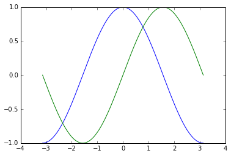

```python
# the most basic plot
pyl.plot(X,C)
pyl.plot(X,S)

pyl.show()
```

## Instantiating defaults

> In the script below, we've instantiated (and commented) all the figure settings that influence the appearance of the plot. The settings have been explicitly set to their default values, but now you can interactively play with the values to explore their affect (see Line properties and Line styles below).

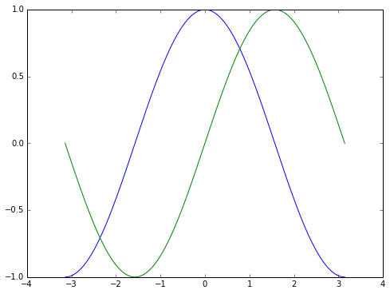

```python
# Create a new figure of size 8x6 points, using 80 dots per inch
pyl.figure(figsize=(8,6), dpi=80)

# Create a new subplot from a grid of 1x1
pyl.subplot(1,1,1)


# Plot cosine using blue color with a continuous line of width 1 (pixels)
pyl.plot(X, C, color="blue", linewidth=1.0, linestyle="-")

# Plot sine using green color with a continuous line of width 1 (pixels)
pyl.plot(X, S, color="green", linewidth=1.0, linestyle="-")

# Set x limits
pyl.xlim(-4.0,4.0)

# Set x ticks
pyl.xticks(np.linspace(-4,4,9,endpoint=True))

# Set y limits
pyl.ylim(-1.0,1.0)

# Set y ticks
pyl.yticks(np.linspace(-1,1,5,endpoint=True))

# Save figure using 72 dots per inch
# savefig("exercice_2.png",dpi=72)

# Show result on screen
pyl.show()
```

## Changing colors and line widths

> First step, we want to have the cosine in blue and the sine in red and a slighty thicker line for both of them. We'll also slightly alter the figure size to make it more horizontal.

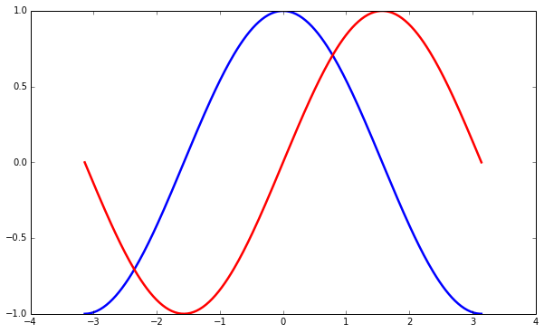

```python
pyl.figure(figsize=(10,6), dpi=80)
pyl.plot(X, C, color="blue", linewidth=2.5, linestyle="-")
pyl.plot(X, S, color="red",  linewidth=2.5, linestyle="-")
```

## Setting limits

> Current limits of the figure are a bit too tight and we want to make some space in order to clearly see all data points.

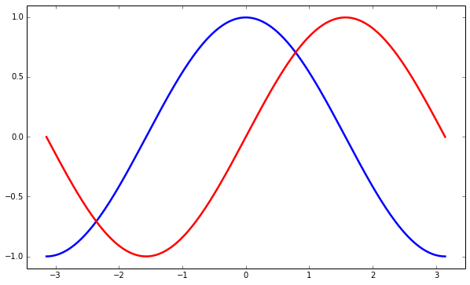

```python
pyl.figure(figsize=(10,6), dpi=80)

# set limits
pyl.xlim(X.min()*1.1, X.max()*1.1)
pyl.ylim(C.min()*1.1, C.max()*1.1)

# plot the chart
pyl.plot(X, C, color="blue", linewidth=2.5, linestyle="-")
pyl.plot(X, S, color="red",  linewidth=2.5, linestyle="-")
```

## Setting ticks

> Current ticks are not ideal because they do not show the interesting values (+/-π,+/-π/2) for sine and cosine. We'll change them such that they show only these values.

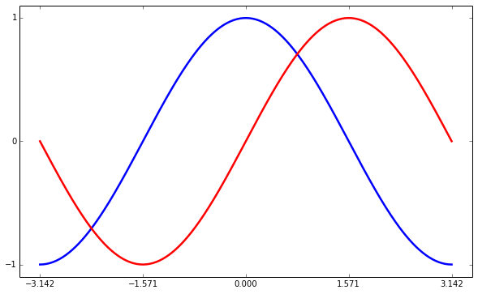

```python
pyl.figure(figsize=(10,6), dpi=80)

# set limits
pyl.xlim(X.min()*1.1, X.max()*1.1)
pyl.ylim(C.min()*1.1, C.max()*1.1)

# set tick marks
pyl.xticks( [-np.pi, -np.pi/2, 0, np.pi/2, np.pi])
pyl.yticks([-1, 0, +1])

# plot the chart
pyl.plot(X, C, color="blue", linewidth=2.5, linestyle="-")
pyl.plot(X, S, color="red",  linewidth=2.5, linestyle="-")
```

## Setting tick labels

> Ticks are now properly placed but their label is not very explicit. We could guess that 3.142 is π but it would be better to make it explicit. When we set tick values, we can also provide a corresponding label in the second argument list. Note that we'll use latex to allow for nice rendering of the label.

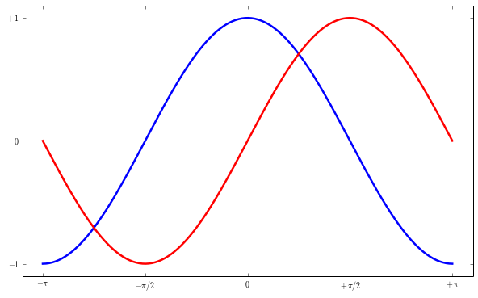

```python
pyl.figure(figsize=(10,6), dpi=80)

# set limits
pyl.xlim(X.min()*1.1, X.max()*1.1)
pyl.ylim(C.min()*1.1, C.max()*1.1)

# set tick spacing
pyl.xticks( [-np.pi, -np.pi/2, 0, np.pi/2, np.pi])
pyl.yticks([-1, 0, +1])

# set tick labels
pyl.xticks([-np.pi, -np.pi/2, 0, np.pi/2, np.pi],
       [r'$-\pi$', r'$-\pi/2$', r'$0$', r'$+\pi/2$', r'$+\pi$'])

pyl.yticks([-1, 0, +1],
       [r'$-1$', r'$0$', r'$+1$'])

# plot the chart
pyl.plot(X, C, color="blue", linewidth=2.5, linestyle="-")
pyl.plot(X, S, color="red",  linewidth=2.5, linestyle="-")
```

## Moving spines

> Spines are the lines connecting the axis tick marks and noting the boundaries of the data area. They can be placed at arbitrary positions and until now, they were on the border of the axis. We'll change that since we want to have them in the middle. Since there are four of them (top/bottom/left/right), we'll discard the top and right by setting their color to none and we'll move the bottom and left ones to coordinate 0 in data space coordinates.

[figure not shown]

```python
pyl.figure(figsize=(10,6), dpi=80)

# set limits
pyl.xlim(X.min()*1.1, X.max()*1.1)
pyl.ylim(C.min()*1.1, C.max()*1.1)

# set tick spacing
pyl.xticks( [-np.pi, -np.pi/2, 0, np.pi/2, np.pi])
pyl.yticks([-1, 0, +1])

# set tick labels
pyl.xticks([-np.pi, -np.pi/2, 0, np.pi/2, np.pi],
       [r'$-\pi$', r'$-\pi/2$', r'$0$', r'$+\pi/2$', r'$+\pi$'])

pyl.yticks([-1, 0, +1],
       [r'$-1$', r'$0$', r'$+1$'])

# move spines to the middle
ax = pyl.gca()
ax.spines['right'].set_color('none')
ax.spines['top'].set_color('none')
ax.xaxis.set_ticks_position('bottom')
ax.spines['bottom'].set_position(('data',0))
ax.yaxis.set_ticks_position('left')
ax.spines['left'].set_position(('data',0))

# plot the chart
pyl.plot(X, C, color="blue", linewidth=2.5, linestyle="-")
pyl.plot(X, S, color="red",  linewidth=2.5, linestyle="-")
```

## Adding a legend

> Let's add a legend in the upper left corner. This only requires adding the keyword argument label (that will be used in the legend box) to the plot commands.

[figure not shown]

```python
pyl.figure(figsize=(10,6), dpi=80)

# set limits
pyl.xlim(X.min()*1.1, X.max()*1.1)
pyl.ylim(C.min()*1.1, C.max()*1.1)

# set tick spacing
pyl.xticks( [-np.pi, -np.pi/2, 0, np.pi/2, np.pi])
pyl.yticks([-1, 0, +1])

# set tick labels
pyl.xticks([-np.pi, -np.pi/2, 0, np.pi/2, np.pi],
       [r'$-\pi$', r'$-\pi/2$', r'$0$', r'$+\pi/2$', r'$+\pi$'])

pyl.yticks([-1, 0, +1],
       [r'$-1$', r'$0$', r'$+1$'])

# move spines to the middle
ax = pyl.gca()
ax.spines['right'].set_color('none')
ax.spines['top'].set_color('none')
ax.xaxis.set_ticks_position('bottom')
ax.spines['bottom'].set_position(('data',0))
ax.yaxis.set_ticks_position('left')
ax.spines['left'].set_position(('data',0))

# plot the chart, this time including a legend
pyl.plot(X, C, color="blue", linewidth=2.5, linestyle="-", label="cosine")
pyl.plot(X, S, color="red",  linewidth=2.5, linestyle="-", label="sine")
pyl.legend(loc='upper left')
```

## Annotate some points

> Let's annotate some interesting points using the annotate command. We chose the 2π/3 value and we want to annotate both the sine and the cosine. We'll first draw a marker on the curve as well as a straight dotted line. Then, we'll use the annotate command to display some text with an arrow.

[figure not shown]

```python
pyl.figure(figsize=(10,6), dpi=80)

# set limits
pyl.xlim(X.min()*1.1, X.max()*1.1)
pyl.ylim(C.min()*1.1, C.max()*1.1)

# set tick spacing
pyl.xticks( [-np.pi, -np.pi/2, 0, np.pi/2, np.pi])
pyl.yticks([-1, 0, +1])

# set tick labels
pyl.xticks([-np.pi, -np.pi/2, 0, np.pi/2, np.pi],
       [r'$-\pi$', r'$-\pi/2$', r'$0$', r'$+\pi/2$', r'$+\pi$'])

pyl.yticks([-1, 0, +1],
       [r'$-1$', r'$0$', r'$+1$'])

# move spines to the middle
ax = pyl.gca()
ax.spines['right'].set_color('none')
ax.spines['top'].set_color('none')
ax.xaxis.set_ticks_position('bottom')
ax.spines['bottom'].set_position(('data',0))
ax.yaxis.set_ticks_position('left')
ax.spines['left'].set_position(('data',0))

# plot the chart, this time including a legend
pyl.plot(X, C, color="blue", linewidth=2.5, linestyle="-", label="cosine")
pyl.plot(X, S, color="red",  linewidth=2.5, linestyle="-", label="sine")
pyl.legend(loc='upper left')

# set up annotations
t = 2*np.pi/3
pyl.plot([t,t],[0,np.cos(t)], color ='blue', linewidth=2.5, linestyle="--")
pyl.scatter([t,],[np.cos(t),], 50, color ='blue')

pyl.annotate(r'$\sin(\frac{2\pi}{3})=\frac{\sqrt{3}}{2}$',
         xy=(t, np.sin(t)), xycoords='data',
         xytext=(+10, +30), textcoords='offset points', fontsize=16,
         arrowprops=dict(arrowstyle="->", connectionstyle="arc3,rad=.2"))

pyl.plot([t,t],[0,np.sin(t)], color ='red', linewidth=2.5, linestyle="--")
pyl.scatter([t,],[np.sin(t),], 50, color ='red')

pyl.annotate(r'$\cos(\frac{2\pi}{3})=-\frac{1}{2}$',
         xy=(t, np.cos(t)), xycoords='data',
         xytext=(-90, -50), textcoords='offset points', fontsize=16,
         arrowprops=dict(arrowstyle="->", connectionstyle="arc3,rad=.2"))
```

## Devil is in the details

> The tick labels are now hardly visible because of the blue and red lines. We can make them bigger and we can also adjust their properties such that they'll be rendered on a semi-transparent white background. This will allow us to see both the data and the labels.

[figure not shown]

```python
pyl.figure(figsize=(10,6), dpi=80)

# set limits
pyl.xlim(X.min()*1.1, X.max()*1.1)
pyl.ylim(C.min()*1.1, C.max()*1.1)

# set tick spacing
pyl.xticks( [-np.pi, -np.pi/2, 0, np.pi/2, np.pi])
pyl.yticks([-1, 0, +1])

# set tick labels
pyl.xticks([-np.pi, -np.pi/2, 0, np.pi/2, np.pi],
       [r'$-\pi$', r'$-\pi/2$', r'$0$', r'$+\pi/2$', r'$+\pi$'])

pyl.yticks([-1, 0, +1],
       [r'$-1$', r'$0$', r'$+1$'])

# move spines to the middle
ax = pyl.gca()
ax.spines['right'].set_color('none')
ax.spines['top'].set_color('none')
ax.xaxis.set_ticks_position('bottom')
ax.spines['bottom'].set_position(('data',0))
ax.yaxis.set_ticks_position('left')
ax.spines['left'].set_position(('data',0))

# plot the chart, this time including a legend
pyl.plot(X, C, color="blue", linewidth=2.5, linestyle="-", label="cosine")
pyl.plot(X, S, color="red",  linewidth=2.5, linestyle="-", label="sine")
pyl.legend(loc='upper left')

# set up annotations
t = 2*np.pi/3
pyl.plot([t,t],[0,np.cos(t)], color ='blue', linewidth=2.5, linestyle="--")
pyl.scatter([t,],[np.cos(t),], 50, color ='blue')

pyl.annotate(r'$\sin(\frac{2\pi}{3})=\frac{\sqrt{3}}{2}$',
         xy=(t, np.sin(t)), xycoords='data',
         xytext=(+10, +30), textcoords='offset points', fontsize=16,
         arrowprops=dict(arrowstyle="->", connectionstyle="arc3,rad=.2"))

pyl.plot([t,t],[0,np.sin(t)], color ='red', linewidth=2.5, linestyle="--")
pyl.scatter([t,],[np.sin(t),], 50, color ='red')

pyl.annotate(r'$\cos(\frac{2\pi}{3})=-\frac{1}{2}$',
         xy=(t, np.cos(t)), xycoords='data',
         xytext=(-90, -50), textcoords='offset points', fontsize=16,
         arrowprops=dict(arrowstyle="->", connectionstyle="arc3,rad=.2"))

# Adjust the tick labels to make them more readable
for label in ax.get_xticklabels() + ax.get_yticklabels():
    label.set_fontsize(16)
    label.set_bbox(dict(facecolor='white', edgecolor='None', alpha=0.65 ))
```

# Before - Defaults only

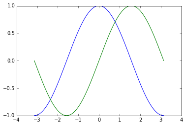

```python
# the most basic plot
pyl.plot(X,C)
pyl.plot(X,S)

pyl.show()
```

# After - with all customizations

[figure not shown]

```python
pyl.figure(figsize=(10,6), dpi=80)

# set limits
pyl.xlim(X.min()*1.1, X.max()*1.1)
pyl.ylim(C.min()*1.1, C.max()*1.1)

# set tick spacing
pyl.xticks( [-np.pi, -np.pi/2, 0, np.pi/2, np.pi])
pyl.yticks([-1, 0, +1])

# set tick labels
pyl.xticks([-np.pi, -np.pi/2, 0, np.pi/2, np.pi],
       [r'$-\pi$', r'$-\pi/2$', r'$0$', r'$+\pi/2$', r'$+\pi$'])

pyl.yticks([-1, 0, +1],
       [r'$-1$', r'$0$', r'$+1$'])

# move spines to the middle
ax = pyl.gca()
ax.spines['right'].set_color('none')
ax.spines['top'].set_color('none')
ax.xaxis.set_ticks_position('bottom')
ax.spines['bottom'].set_position(('data',0))
ax.yaxis.set_ticks_position('left')
ax.spines['left'].set_position(('data',0))

# plot the chart, this time including a legend
pyl.plot(X, C, color="blue", linewidth=2.5, linestyle="-", label="cosine")
pyl.plot(X, S, color="red",  linewidth=2.5, linestyle="-", label="sine")
pyl.legend(loc='upper left')

# set up annotations
t = 2*np.pi/3
pyl.plot([t,t],[0,np.cos(t)], color ='blue', linewidth=2.5, linestyle="--")
pyl.scatter([t,],[np.cos(t),], 50, color ='blue')

pyl.annotate(r'$\sin(\frac{2\pi}{3})=\frac{\sqrt{3}}{2}$',
         xy=(t, np.sin(t)), xycoords='data',
         xytext=(+10, +30), textcoords='offset points', fontsize=16,
         arrowprops=dict(arrowstyle="->", connectionstyle="arc3,rad=.2"))

pyl.plot([t,t],[0,np.sin(t)], color ='red', linewidth=2.5, linestyle="--")
pyl.scatter([t,],[np.sin(t),], 50, color ='red')

pyl.annotate(r'$\cos(\frac{2\pi}{3})=-\frac{1}{2}$',
         xy=(t, np.cos(t)), xycoords='data',
         xytext=(-90, -50), textcoords='offset points', fontsize=16,
         arrowprops=dict(arrowstyle="->", connectionstyle="arc3,rad=.2"))

# Adjust the tick labels to make them more readable
for label in ax.get_xticklabels() + ax.get_yticklabels():
    label.set_fontsize(16)
    label.set_bbox(dict(facecolor='white', edgecolor='None', alpha=0.65 ))
```

> This piece of the tutorial is adapted from a fantastic matplotlib tutorial located here: [Matplotlib tutorial](http://www.labri.fr/perso/nrougier/teaching/matplotlib/)

## Extending Matplotlib

- We will follow along with a great tutorial by Randal Olson.
- His post is here: [How to make beautiful data visualizations in Python with matplotlib](http://www.randalolson.com/2014/06/28/how-to-make-beautiful-data-visualizations-in-python-with-matplotlib/)

#### The Basics

- We'll load our packages
- Change the default color scheme used by matplotlib.
- As we saw yesterday, it's pretty saturated, bright, and, dare we say, ugly.
- Randal prefers the Tableau color map and I agree. It's a better look than the alternatives.
  - [Tableau](http://www.tableau.com) is a visualization tool that rocks. It's paid software though - about $1,000 / seat.

### We will start by reproducing this plot:

```python
IFrame("http://www.randalolson.com/wp-content/uploads/"
       "percent-bachelors-degrees-women-usa.png",
       1000, 1000)
```

[interactive chart not shown]

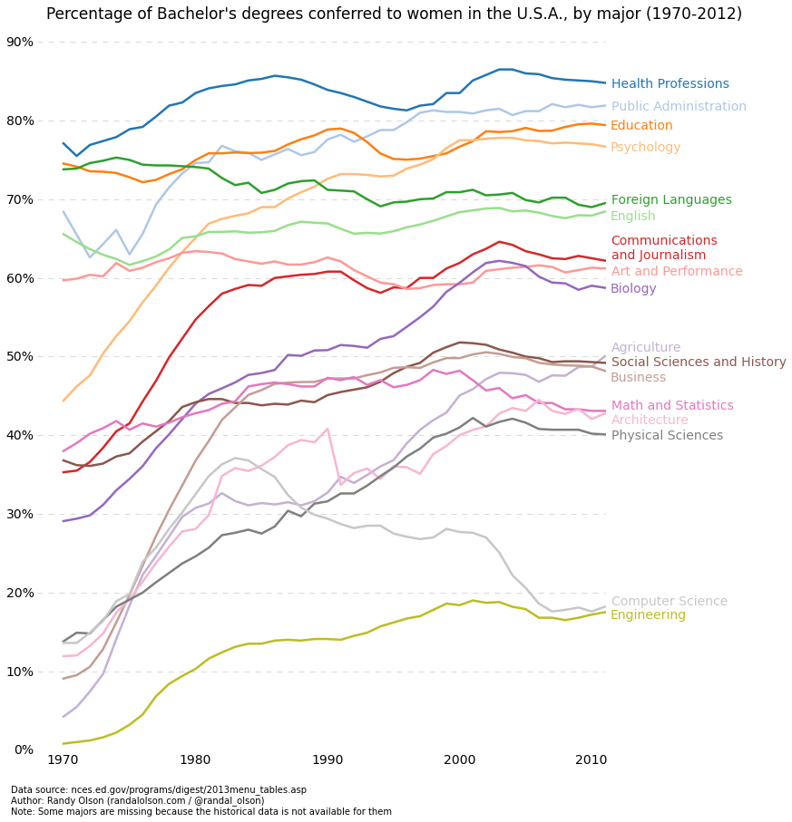

```python
# Read the data into a pandas DataFrame.
gender_degree_data = pd.read_csv("http://www.randalolson.com/wp-content/uploads/percent-bachelors-degrees-women-usa.csv")

# These are the "Tableau 20" colors as RGB.
tableau20 = [(31, 119, 180), (174, 199, 232), (255, 127, 14), (255, 187, 120),
             (44, 160, 44), (152, 223, 138), (214, 39, 40), (255, 152, 150),
             (148, 103, 189), (197, 176, 213), (140, 86, 75), (196, 156, 148),
             (227, 119, 194), (247, 182, 210), (127, 127, 127), (199, 199, 199),
             (188, 189, 34), (219, 219, 141), (23, 190, 207), (158, 218, 229)]

# Scale the RGB values to the [0, 1] range, which is the format matplotlib accepts.
for i in range(len(tableau20)):
    r, g, b = tableau20[i]
    tableau20[i] = (r / 255., g / 255., b / 255.)

# You typically want your plot to be ~1.33x wider than tall. This plot is a rare
# exception because of the number of lines being plotted on it.
# Common sizes: (10, 7.5) and (12, 9)
pyl.figure(figsize=(12, 14))

# Remove the plot frame lines. They are unnecessary chartjunk.
ax = pyl.subplot(111)
ax.spines["top"].set_visible(False)
ax.spines["bottom"].set_visible(False)
ax.spines["right"].set_visible(False)
ax.spines["left"].set_visible(False)

# Ensure that the axis ticks only show up on the bottom and left of the plot.
# Ticks on the right and top of the plot are generally unnecessary chartjunk.
ax.get_xaxis().tick_bottom()
ax.get_yaxis().tick_left()

# Limit the range of the plot to only where the data is.
# Avoid unnecessary whitespace.
pyl.ylim(0, 90)
pyl.xlim(1968, 2014)

# Make sure your axis ticks are large enough to be easily read.
# You don't want your viewers squinting to read your plot.
pyl.yticks(range(0, 91, 10), [str(x) + "%" for x in range(0, 91, 10)], fontsize=14)
pyl.xticks(fontsize=14)

# Provide tick lines across the plot to help your viewers trace along
# the axis ticks. Make sure that the lines are light and small so they
# don't obscure the primary data lines.
for y in range(10, 91, 10):
    plt.plot(range(1968, 2012), [y] * len(range(1968, 2012)), "--", lw=0.5, color="black", alpha=0.3)

# Remove the tick marks; they are unnecessary with the tick lines we just plotted.
plt.tick_params(axis="both", which="both", bottom="off", top="off",
                labelbottom="on", left="off", right="off", labelleft="on")

# Now that the plot is prepared, it's time to actually plot the data!
# Note that I plotted the majors in order of the highest % in the final year.
majors = ['Health Professions', 'Public Administration', 'Education', 'Psychology',
          'Foreign Languages', 'English', 'Communications\nand Journalism',
          'Art and Performance', 'Biology', 'Agriculture',
          'Social Sciences and History', 'Business', 'Math and Statistics',
          'Architecture', 'Physical Sciences', 'Computer Science',
          'Engineering']

for rank, column in enumerate(majors):
    # Plot each line separately with its own color, using the Tableau 20
    # color set in order.
    plt.plot(gender_degree_data.Year.values,
            gender_degree_data[column.replace("\n", " ")].values,
            lw=2.5, color=tableau20[rank])

    # Add a text label to the right end of every line. Most of the code below
    # is adding specific offsets y position because some labels overlapped.
    pyl.y_pos = gender_degree_data[column.replace("\n", " ")].values[-1] - 0.5
    if column == "Foreign Languages":
        pyl.y_pos += 0.5
    elif column == "English":
        pyl.y_pos -= 0.5
    elif column == "Communications\nand Journalism":
        pyl.y_pos += 0.75
    elif column == "Art and Performance":
        pyl.y_pos -= 0.25
    elif column == "Agriculture":
        pyl.y_pos += 1.25
    elif column == "Social Sciences and History":
        pyl.y_pos += 0.25
    elif column == "Business":
        pyl.y_pos -= 0.75
    elif column == "Math and Statistics":
        pyl.y_pos += 0.75
    elif column == "Architecture":
        pyl.y_pos -= 0.75
    elif column == "Computer Science":
        pyl.y_pos += 0.75
    elif column == "Engineering":
        pyl.y_pos -= 0.25

    # Again, make sure that all labels are large enough to be easily read
    # by the viewer.
    pyl.text(2011.5, pyl.y_pos, column, fontsize=14, color=tableau20[rank])

# matplotlib's title() call centers the title on the plot, but not the graph,
# so I used the text() call to customize where the title goes.

# Make the title big enough so it spans the entire plot, but don't make it
# so big that it requires two lines to show.

# Note that if the title is descriptive enough, it is unnecessary to include
# axis labels; they are self-evident, in this plot's case.
pyl.text(1995, 93, "Percentage of Bachelor's degrees conferred to women in the U.S.A."
       ", by major (1970-2012)", fontsize=17, ha="center")

# Always include your data source(s) and copyright notice! And for your
# data sources, tell your viewers exactly where the data came from,
# preferably with a direct link to the data. Just telling your viewers
# that you used data from the "U.S. Census Bureau" is completely useless:
# the U.S. Census Bureau provides all kinds of data, so how are your
# viewers supposed to know which data set you used?
pyl.text(1966, -8, "Data source: nces.ed.gov/programs/digest/2013menu_tables.asp"
       "\nAuthor: Randy Olson (randalolson.com / @randal_olson)"
       "\nNote: Some majors are missing because the historical data "
       "is not available for them", fontsize=10)

# Finally, save the figure as a PNG.
# You can also save it as a PDF, JPEG, etc.
# Just change the file extension in this call.
# bbox_inches="tight" removes all the extra whitespace on the edges of your plot.
#savefig("percent-bachelors-degrees-women-usa.png", bbox_inches="tight");
dataviz = plt.gcf()
```

# Plot.ly - Let's make this graphic interactive

- What is [plot.ly](https://plot.ly/)?
- Set up plotly with Python:

`$ pip install plotly`

- Set up an account on plotly and use your API and credentials to access the service:
- Follow the instructions here to use the API: [Install Instructions](http://nbviewer.ipython.org/github/plotly/python-user-guide/blob/master/s00_homepage/s00_homepage.ipynb#Installation-guidelines)

**Let's get to it**

```python
# import my plotly items
# note that with Python I can import modules anywhere - that's good!
import plotly.plotly as ply
import plotly.tools as tls
```

```python
# We can convert our matplotlib figure object with one line of code.
ply.iplot_mpl(dataviz, resize=False, filename='dataviz', width=960, height=1120)
```

[interactive chart not shown]

#### Close but we're not there - two warnings:

`Looks like the annotation(s) you are trying to draw lies/lay outside the given figure size.`

`Looks like you used a newline character: '\n'.`

**What do we do?**

- Adjust the margins.
- Remove ticks in this Python session.
- The title is not exactly at the same position as on the original matplotlib figure. Therefore, we will add a Plotly title which additionally will make the figure's URL more descriptive.
- And finally, we will make full use of Plotly's interactibility by adding hover text to the data traces.

```python
dataviz_plotly = tls.mpl_to_plotly(dataviz)

# show plotly figure object in notebook
# so we can see what the underlying plot looks like
print dataviz_plotly.to_string()
```

[output not shown]

[output cut: 667 more lines]

[output not shown]

```python
# List of all annotation texts, show it in notebook
annos_text = [anno['text'] for anno in dataviz_plotly['layout']['annotations']]
annos_text
```

```
['Health Professions',
 'Public Administration',
 'Education',
 'Psychology',
 'Foreign Languages',
 'English',
 'Communications\nand Journalism',
 'Art and Performance',
 'Biology',
 'Agriculture',
 'Social Sciences and History',
 'Business',
 'Math and Statistics',
 'Architecture',
 'Physical Sciences',
 'Computer Science',
 'Engineering',
 "Percentage of Bachelor's degrees conferred to women in the U.S.A., by major (1970-2012)",
 'Data source: nces.ed.gov/programs/digest/2013menu_tables.asp\nAuthor: Randy Olson (randalolson.com / @randal_olson)\nNote: Some majors are missing because the historical data is not available for them']
```

```python
# List all majors in dataset, show it in notebook
majors = annos_text[:-2]
majors
```

```
['Health Professions',
 'Public Administration',
 'Education',
 'Psychology',
 'Foreign Languages',
 'English',
 'Communications\nand Journalism',
 'Art and Performance',
 'Biology',
 'Agriculture',
 'Social Sciences and History',
 'Business',
 'Math and Statistics',
 'Architecture',
 'Physical Sciences',
 'Computer Science',
 'Engineering']
```

```python
# (1) Adjust margins (use our web GUI to easier find the appropriate values)
dataviz_plotly['layout']['margin'].update(
    l=50,   # left margin in pixels
    r=160,  # right " " "
    b=100,  # bottom " " "
    t=100   # top " " "
)

# (2) Add title (appears in figure's URL, nice for sharing), remove title annotation
dataviz_plotly['layout'].update(
    title=annos_text[-2],
    titlefont=dict(size=20)  # increase font size
)
dataviz_plotly['layout']['annotations'][-2].update(text=' ')

# (3) Remove tick lines
dataviz_plotly['layout']['xaxis1'].update(ticks='')
dataviz_plotly['layout']['yaxis1'].update(ticks='')

# (4) Add hover label to data trace, remove hover label from grid traces
N_traces = len(dataviz_plotly['data'])
N_majors = len(majors)
update_name = [{'name': ' '} for i in range(N_traces)]
update_name[N_traces-N_majors:] = [{'name': major} for major in majors]
dataviz_plotly['data'].update(update_name)

# (5) Make every y coordinate show when hovering over a given x coordinate
dataviz_plotly['layout'].update(hovermode='x')
```

```python
ply.iplot(dataviz_plotly, filename='dataviz_updated', width=960, height=1120)
```

[interactive chart not shown]

### Additional Plotly Resources:

- [Python Page](https://plot.ly/python/)
- [User Guide](http://nbviewer.ipython.org/github/plotly/python-user-guide/blob/master/s00_homepage/s00_homepage.ipynb)